# Importing data from statistical software packages

## Import SAS data with haven

**haven** es un paquete que es extremadamente sencillo de usar para importar datos de tres tipos de software: SAS, STATA y SPSS. Dependiendo del tipo de software haremos uso de distintas funciones

- SAS: **read_sas()**
- STATA: **read_dta()** (o **read_stata()** los cuales tienen un función idéntica)
- SPSS: **read_sav()** o **read_por()** dependiendo del tipo de fichero

Todas esta funciones toman un único argumento: el path de tu fichero en local. Incluso si le pasamos una URL, **haven** descargará de forma automática el fichero y lo importará.

```r
#Importamos librería haven
library(haven)
#Importamos el fichero sales.sas7bdat
sales <- read_sas("sales.sas7bdat")
#Mostramos la estructura de sales
str(sales)
```

```
Classes tbl_df, tbl and 'data.frame':   431 obs. of  4 variables:
 $ purchase: num  0 0 1 1 0 0 0 0 0 0 ...
 $ age     : num  41 47 41 39 32 32 33 45 43 40 ...
 $ gender  : chr  "Female" "Female" "Female" "Female" ...
 $ income  : chr  "Low" "Low" "Low" "Low" ...
 - attr(*, "label")= chr "SALES"
```

## Import STATA data with haven

Cuando inspeccionamos el resultado de **read_dta()**, podemos notar que la primera columna es importada como un vector de clase **labelled**, esto es una estructura común en R cuando importamos de otros entornos estadísticos. En lugar de continuar trabajando con este tipo de dato, es mejor cambiar estos datos a una clase estándar de R. Para convertir una variable de tipo **labelled** a factor, necesitamos la función **as_factor()**

```r
#Importamos el fichero sugar desde la URL
sugar <- read_dta("http://assets.datacamp.com/production/course_1478/datasets/trade.dta")
#Mostramos la estructura de sugar
str(sugar)
```

```
Classes tbl_df, tbl and 'data.frame':   10 obs. of  5 variables:
 $ Date    :Class 'labelled'  atomic [1:10] 10 9 8 7 6 5 4 3 2 1
  .. ..- attr(*, "label")= chr "Date"
  .. ..- attr(*, "format.stata")= chr "%9.0g"
  .. ..- attr(*, "labels")= Named num [1:10] 1 2 3 4 5 6 7 8 9 10
  .. .. ..- attr(*, "names")= chr [1:10] "2004-12-31" "2005-12-31" "2006-12-31" "2007-12-31" ...
 $ Import  : atomic  37664782 16316512 11082246 35677943 9879878 ...
  ..- attr(*, "label")= chr "Import"
  ..- attr(*, "format.stata")= chr "%9.0g"
 $ Weight_I: atomic  54029106 21584365 14526089 55034932 14806865 ...
  ..- attr(*, "label")= chr "Weight_I"
  ..- attr(*, "format.stata")= chr "%9.0g"
 $ Export  : atomic  5.45e+07 1.03e+08 3.79e+07 4.85e+07 7.15e+07 ...
  ..- attr(*, "label")= chr "Export"
  ..- attr(*, "format.stata")= chr "%9.0g"
 $ Weight_E: atomic  9.34e+07 1.58e+08 8.80e+07 1.12e+08 1.32e+08 ...
  ..- attr(*, "label")= chr "Weight_E"
  ..- attr(*, "format.stata")= chr "%9.0g"
 - attr(*, "label")= chr "Written by R."
```

```r
#Convertimos los valores de la columna Date a tipo date
sugar$Date <- as.Date(as_factor(sugar$Date))
#Volvemos a mostrar la estructura de sugar
str(sugar)
```

```
Classes tbl_df, tbl and 'data.frame':   10 obs. of  5 variables:
 $ Date    : Date, format: "2013-12-31" "2012-12-31" ...
 $ Import  : atomic  37664782 16316512 11082246 35677943 9879878 ...
  ..- attr(*, "label")= chr "Import"
  ..- attr(*, "format.stata")= chr "%9.0g"
 $ Weight_I: atomic  54029106 21584365 14526089 55034932 14806865 ...
  ..- attr(*, "label")= chr "Weight_I"
  ..- attr(*, "format.stata")= chr "%9.0g"
 $ Export  : atomic  5.45e+07 1.03e+08 3.79e+07 4.85e+07 7.15e+07 ...
  ..- attr(*, "label")= chr "Export"
  ..- attr(*, "format.stata")= chr "%9.0g"
 $ Weight_E: atomic  9.34e+07 1.58e+08 8.80e+07 1.12e+08 1.32e+08 ...
  ..- attr(*, "label")= chr "Weight_E"
  ..- attr(*, "format.stata")= chr "%9.0g"
 - attr(*, "label")= chr "Written by R."
```

## Import SPSS data with haven

El paquete **haven** también nos permite importar ficheros desde SPSS. Dependiendo del tipo de fichero haremos uso de **read_sav()** para los ficheros **.sav** o **read_por()** para los ficheros **.por**.

```r
#Importamos el fichero
traits <- read_sav("person.sav")
#Hacemos un summary
summary(traits)
```

```
    Neurotic      Extroversion   Agreeableness   Conscientiousness
 Min.   : 0.00   Min.   : 5.00   Min.   :15.00   Min.   : 7.00
 1st Qu.:18.00   1st Qu.:26.00   1st Qu.:39.00   1st Qu.:25.00
 Median :24.00   Median :31.00   Median :45.00   Median :30.00
 Mean   :23.63   Mean   :30.23   Mean   :44.55   Mean   :30.85
 3rd Qu.:29.00   3rd Qu.:34.00   3rd Qu.:50.00   3rd Qu.:36.00
 Max.   :44.00   Max.   :65.00   Max.   :73.00   Max.   :58.00
 NA's   :14      NA's   :16      NA's   :19      NA's   :14
```

```r
#Hacemos una selección de aquellas personas que tienen una puntuación superior a 40 en las  #variables Extroversion y Agreeableness
subset(traits, Extroversion > 40 & Agreeableness > 40)
```

| Neurotic | Extroversion | Agreeableness | Conscientiousness |
| --- | --- | --- | --- |
| 38 | 43 | 49 | 29 |
| 20 | 42 | 46 | 31 |
| 18 | 42 | 49 | 31 |
| 42 | 43 | 44 | 29 |
| 30 | 42 | 51 | 24 |
| 18 | 42 | 50 | 25 |
| 27 | 45 | 55 | 23 |
| 18 | 43 | 57 | 34 |

## Factorize, round two

Cuando importamos desde ficheros SPSS, es posible que algunas de las variables importadas sean de tipo **labelled**. Esto es debido a que trata de mantener la información de los ficheros originales.

```r
#Importamos los datos
work <- read_sav("http://s3.amazonaws.com/assets.datacamp.com/production/course_1478/datasets/employee.sav")
#Hacemos un summary de work$GENDER
summary(work$GENDER)
```

```
   Length     Class      Mode
      474  labelled character
```

```r
#Convertimos a factor
work$GENDER <- as_factor(work$GENDER)
#Hacemos un summary
summary(work$GENDER)
```

```
Female   Male
   216    258
```

## Import STATA data with foreign (I)

El paquete **foreign** nos ofrece la función **read.dta()** para importar ficheros STATA. Le podemos pasar o bien el path o bien la URL.

```r
#Cargamos librería
library(foreign)
#Exportamos los datos
florida <- read.dta("florida.dta")
#Mostamos las últimas observaciones
tail(florida)
```

|  | gore | bush | buchanan | nader | total |
| --- | --- | --- | --- | --- | --- |
| 62 | 2647 | 4051 | 27 | 59 | 6784 |
| 63 | 1399 | 2326 | 26 | 29 | 3780 |
| 64 | 97063 | 82214 | 396 | 2436 | 182109 |
| 65 | 3835 | 4511 | 46 | 149 | 8541 |
| 66 | 5637 | 12176 | 120 | 265 | 18198 |
| 67 | 2796 | 4983 | 88 | 93 | 7960 |

## Import STATA data with foreign (II)

Los datos pueden ser muy diversos, desde vectores de caracteres a variables categóricas, fechas etc. Para estos la función **read.dta()** dispone de argumentos adicionales.

Los argumentos que son usados con más frecuencia son **convert.dates**, **convert.factors**, **missing.type** y **convert.underscore**

```r
#Realizamos la primera lectura sin pasar ningún parámetro
edu_equal_1 <- read.dta("edequality.dta")
str(edu_equal_1)
```

```
'data.frame':   12214 obs. of  27 variables:
 $ hhid              : num  1 1 1 2 2 3 4 4 5 6 ...
 $ hhweight          : num  627 627 627 627 627 ...
 $ location          : Factor w/ 2 levels "urban location",..: 1 1 1 1 1 2 2 2 1 1 ...
 $ region            : Factor w/ 9 levels "Sofia city","Bourgass",..: 8 8 8 9 9 4 4 4 8 8 ...
 $ ethnicity_head    : Factor w/ 4 levels "Bulgaria","Turks",..: 2 2 2 1 1 1 1 1 1 1 ...
 $ age               : num  37 11 8 73 70 75 79 80 82 83 ...
 $ gender            : Factor w/ 2 levels "male","female": 2 2 1 1 2 1 1 2 2 2 ...
 $ relation          : Factor w/ 9 levels "head                      ",..: 1 3 3 1 2 1 1 2 1 1 ...
 $ literate          : Factor w/ 2 levels "no","yes": 1 2 2 2 2 2 2 2 2 2 ...
 $ income_mnt        : num  13.3 13.3 13.3 142.5 142.5 ...
 $ income            : num  160 160 160 1710 1710 ...
 $ aggregate         : num  1042 1042 1042 3271 3271 ...
 $ aggr_ind_annual   : num  347 347 347 1635 1635 ...
 $ educ_completed    : int  2 4 4 4 3 3 3 3 4 4 ...
 $ grade_complete    : num  4 3 0 3 4 4 4 4 5 5 ...
 $ grade_all         : num  4 11 8 11 8 8 8 8 13 13 ...
 $ unemployed        : int  2 1 1 1 1 1 1 1 1 1 ...
 $ reason_OLF        : int  NA NA NA 3 3 3 9 9 3 3 ...
 $ sector            : int  NA NA NA NA NA NA 1 1 NA NA ...
 $ occupation        : int  NA NA NA NA NA NA 5 5 NA NA ...
 $ earn_mont         : num  0 0 0 0 0 0 20 20 0 0 ...
 $ earn_ann          : num  0 0 0 0 0 0 240 240 0 0 ...
 $ hours_week        : num  NA NA NA NA NA NA 30 35 NA NA ...
 $ hours_mnt         : num  NA NA NA NA NA ...
 $ fulltime          : int  NA NA NA NA NA NA 1 1 NA NA ...
 $ hhexp             : num  100 100 100 343 343 ...
 $ legacy_pension_amt: num  NA NA NA NA NA NA NA NA NA NA ...
 - attr(*, "datalabel")= chr ""
 - attr(*, "time.stamp")= chr ""
 - attr(*, "formats")= chr  "%9.0g" "%9.0g" "%9.0g" "%9.0g" ...
 - attr(*, "types")= int  100 100 108 108 108 100 108 108 108 100 ...
 - attr(*, "val.labels")= chr  "" "" "location" "region" ...
 - attr(*, "var.labels")= chr  "hhid" "hhweight" "location" "region" ...
 - attr(*, "expansion.fields")=List of 12
  ..$ : chr  "_dta" "_svy_su1" "cluster"
  ..$ : chr  "_dta" "_svy_strata1" "strata"
  ..$ : chr  "_dta" "_svy_stages" "1"
  ..$ : chr  "_dta" "_svy_version" "2"
  ..$ : chr  "_dta" "__XijVarLabcons" "(sum) cons"
```

[output cut: 18 more lines]

```
  .. ..- attr(*, "names")= chr  "head                      " "spouse/partner            " "child                     " "son/daughter-in-law       " ...
  ..$ lit     : Named int  1 2
  .. ..- attr(*, "names")= chr  "no" "yes"
  ..$         : Named int  1 2 3 4
  .. ..- attr(*, "names")= chr  "never attanded" "primary" "secondary" "postsecondary"
  ..$         : Named int  1 2
  .. ..- attr(*, "names")= chr  "Not unemployed" "Unemployed"
  ..$         : Named int  1 2 3 4 5 6 7 8 9 10
  .. ..- attr(*, "names")= chr  "student" "housewife/childcare" "in retirement" "illness, disability" ...
  ..$         : Named int  1 2 3 4 5 6 7 8 9 10
  .. ..- attr(*, "names")= chr  "agriculture" "mining" "manufacturing" "utilities" ...
  ..$         : Named int  1 2 3 4 5
  .. ..- attr(*, "names")= chr  "private company" "public works program" "government,public sector, army" "private individual" ...
  ..$         : Named int  1 2
  .. ..- attr(*, "names")= chr  "no" "yes"
```

```r
#Realizamos la lectura con la variable convert.factors igual a FALSE
edu_equal_2 <- read.dta("edequality.dta", convert.factors = FALSE)
str(edu_equal_2)
```

```
'data.frame':   12214 obs. of  27 variables:
 $ hhid              : num  1 1 1 2 2 3 4 4 5 6 ...
 $ hhweight          : num  627 627 627 627 627 ...
 $ location          : int  1 1 1 1 1 2 2 2 1 1 ...
 $ region            : int  8 8 8 9 9 4 4 4 8 8 ...
 $ ethnicity_head    : int  2 2 2 1 1 1 1 1 1 1 ...
 $ age               : num  37 11 8 73 70 75 79 80 82 83 ...
 $ gender            : int  2 2 1 1 2 1 1 2 2 2 ...
 $ relation          : int  1 3 3 1 2 1 1 2 1 1 ...
 $ literate          : int  1 2 2 2 2 2 2 2 2 2 ...
 $ income_mnt        : num  13.3 13.3 13.3 142.5 142.5 ...
 $ income            : num  160 160 160 1710 1710 ...
 $ aggregate         : num  1042 1042 1042 3271 3271 ...
 $ aggr_ind_annual   : num  347 347 347 1635 1635 ...
 $ educ_completed    : int  2 4 4 4 3 3 3 3 4 4 ...
 $ grade_complete    : num  4 3 0 3 4 4 4 4 5 5 ...
 $ grade_all         : num  4 11 8 11 8 8 8 8 13 13 ...
 $ unemployed        : int  2 1 1 1 1 1 1 1 1 1 ...
 $ reason_OLF        : int  NA NA NA 3 3 3 9 9 3 3 ...
 $ sector            : int  NA NA NA NA NA NA 1 1 NA NA ...
 $ occupation        : int  NA NA NA NA NA NA 5 5 NA NA ...
 $ earn_mont         : num  0 0 0 0 0 0 20 20 0 0 ...
 $ earn_ann          : num  0 0 0 0 0 0 240 240 0 0 ...
 $ hours_week        : num  NA NA NA NA NA NA 30 35 NA NA ...
 $ hours_mnt         : num  NA NA NA NA NA ...
 $ fulltime          : int  NA NA NA NA NA NA 1 1 NA NA ...
 $ hhexp             : num  100 100 100 343 343 ...
 $ legacy_pension_amt: num  NA NA NA NA NA NA NA NA NA NA ...
 - attr(*, "datalabel")= chr ""
 - attr(*, "time.stamp")= chr ""
 - attr(*, "formats")= chr  "%9.0g" "%9.0g" "%9.0g" "%9.0g" ...
 - attr(*, "types")= int  100 100 108 108 108 100 108 108 108 100 ...
 - attr(*, "val.labels")= chr  "" "" "location" "region" ...
 - attr(*, "var.labels")= chr  "hhid" "hhweight" "location" "region" ...
 - attr(*, "expansion.fields")=List of 12
  ..$ : chr  "_dta" "_svy_su1" "cluster"
  ..$ : chr  "_dta" "_svy_strata1" "strata"
  ..$ : chr  "_dta" "_svy_stages" "1"
  ..$ : chr  "_dta" "_svy_version" "2"
  ..$ : chr  "_dta" "__XijVarLabcons" "(sum) cons"
```

[output cut: 18 more lines]

```
  .. ..- attr(*, "names")= chr  "head                      " "spouse/partner            " "child                     " "son/daughter-in-law       " ...
  ..$ lit     : Named int  1 2
  .. ..- attr(*, "names")= chr  "no" "yes"
  ..$         : Named int  1 2 3 4
  .. ..- attr(*, "names")= chr  "never attanded" "primary" "secondary" "postsecondary"
  ..$         : Named int  1 2
  .. ..- attr(*, "names")= chr  "Not unemployed" "Unemployed"
  ..$         : Named int  1 2 3 4 5 6 7 8 9 10
  .. ..- attr(*, "names")= chr  "student" "housewife/childcare" "in retirement" "illness, disability" ...
  ..$         : Named int  1 2 3 4 5 6 7 8 9 10
  .. ..- attr(*, "names")= chr  "agriculture" "mining" "manufacturing" "utilities" ...
  ..$         : Named int  1 2 3 4 5
  .. ..- attr(*, "names")= chr  "private company" "public works program" "government,public sector, army" "private individual" ...
  ..$         : Named int  1 2
  .. ..- attr(*, "names")= chr  "no" "yes"
```

```r
#Volvemos hacer la lectura con convert.underscore = TRUE
edu_equal_3 <- read.dta("edequality.dta", convert.underscore = TRUE)
str(edu_equal_3)
```

```
'data.frame':   12214 obs. of  27 variables:
 $ hhid              : num  1 1 1 2 2 3 4 4 5 6 ...
 $ hhweight          : num  627 627 627 627 627 ...
 $ location          : Factor w/ 2 levels "urban location",..: 1 1 1 1 1 2 2 2 1 1 ...
 $ region            : Factor w/ 9 levels "Sofia city","Bourgass",..: 8 8 8 9 9 4 4 4 8 8 ...
 $ ethnicity.head    : Factor w/ 4 levels "Bulgaria","Turks",..: 2 2 2 1 1 1 1 1 1 1 ...
 $ age               : num  37 11 8 73 70 75 79 80 82 83 ...
 $ gender            : Factor w/ 2 levels "male","female": 2 2 1 1 2 1 1 2 2 2 ...
 $ relation          : Factor w/ 9 levels "head                      ",..: 1 3 3 1 2 1 1 2 1 1 ...
 $ literate          : Factor w/ 2 levels "no","yes": 1 2 2 2 2 2 2 2 2 2 ...
 $ income.mnt        : num  13.3 13.3 13.3 142.5 142.5 ...
 $ income            : num  160 160 160 1710 1710 ...
 $ aggregate         : num  1042 1042 1042 3271 3271 ...
 $ aggr.ind.annual   : num  347 347 347 1635 1635 ...
 $ educ.completed    : int  2 4 4 4 3 3 3 3 4 4 ...
 $ grade.complete    : num  4 3 0 3 4 4 4 4 5 5 ...
 $ grade.all         : num  4 11 8 11 8 8 8 8 13 13 ...
 $ unemployed        : int  2 1 1 1 1 1 1 1 1 1 ...
 $ reason.OLF        : int  NA NA NA 3 3 3 9 9 3 3 ...
 $ sector            : int  NA NA NA NA NA NA 1 1 NA NA ...
 $ occupation        : int  NA NA NA NA NA NA 5 5 NA NA ...
 $ earn.mont         : num  0 0 0 0 0 0 20 20 0 0 ...
 $ earn.ann          : num  0 0 0 0 0 0 240 240 0 0 ...
 $ hours.week        : num  NA NA NA NA NA NA 30 35 NA NA ...
 $ hours.mnt         : num  NA NA NA NA NA ...
 $ fulltime          : int  NA NA NA NA NA NA 1 1 NA NA ...
 $ hhexp             : num  100 100 100 343 343 ...
 $ legacy.pension.amt: num  NA NA NA NA NA NA NA NA NA NA ...
 - attr(*, "datalabel")= chr ""
 - attr(*, "time.stamp")= chr ""
 - attr(*, "formats")= chr  "%9.0g" "%9.0g" "%9.0g" "%9.0g" ...
 - attr(*, "types")= int  100 100 108 108 108 100 108 108 108 100 ...
 - attr(*, "val.labels")= chr  "" "" "location" "region" ...
 - attr(*, "var.labels")= chr  "hhid" "hhweight" "location" "region" ...
 - attr(*, "expansion.fields")=List of 12
  ..$ : chr  "_dta" "_svy_su1" "cluster"
  ..$ : chr  "_dta" "_svy_strata1" "strata"
  ..$ : chr  "_dta" "_svy_stages" "1"
  ..$ : chr  "_dta" "_svy_version" "2"
  ..$ : chr  "_dta" "__XijVarLabcons" "(sum) cons"
```

[output cut: 18 more lines]

```
  .. ..- attr(*, "names")= chr  "head                      " "spouse/partner            " "child                     " "son/daughter-in-law       " ...
  ..$ lit     : Named int  1 2
  .. ..- attr(*, "names")= chr  "no" "yes"
  ..$         : Named int  1 2 3 4
  .. ..- attr(*, "names")= chr  "never attanded" "primary" "secondary" "postsecondary"
  ..$         : Named int  1 2
  .. ..- attr(*, "names")= chr  "Not unemployed" "Unemployed"
  ..$         : Named int  1 2 3 4 5 6 7 8 9 10
  .. ..- attr(*, "names")= chr  "student" "housewife/childcare" "in retirement" "illness, disability" ...
  ..$         : Named int  1 2 3 4 5 6 7 8 9 10
  .. ..- attr(*, "names")= chr  "agriculture" "mining" "manufacturing" "utilities" ...
  ..$         : Named int  1 2 3 4 5
  .. ..- attr(*, "names")= chr  "private company" "public works program" "government,public sector, army" "private individual" ...
  ..$         : Named int  1 2
  .. ..- attr(*, "names")= chr  "no" "yes"
```

## Import SPSS data with foreign (I)

El paquete **foreign** también dispone de la función **read.spss()** para leer ficheros de datos SPSS.

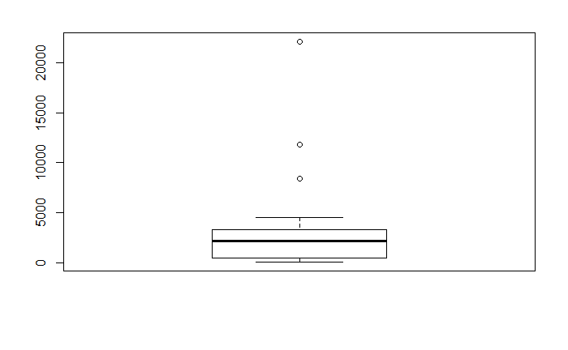

```r
#Importamos los datos
demo <- read.spss("international.sav", to.data.frame = TRUE)
#Hacemos un boxplot de la variable gdp
boxplot(demo$gdp)
```

## Import SPSS data with foreign (II)

En el ejercicio anterior hicimos uso del argumento **to.data.frame** en la función **read.spsss()**, pero existen muchos otros argumentos como por ejemplo **use.value.labels**. Con esta variable indicamos si una variable de labelled debe ser pasada a tipo factor. Por defecto el valor es TRUE lo que nos indica que todas las variables de tipo labelled serán convertidas a tipo factor.

```r
#Importamos international.sav como tipo dataframe
demo_1 <- read.spss("international.sav", to.data.frame = TRUE)
#Mostramos la cabecera
head(demo_1)
```

|  | id | country | contint | m_illit | f_illit | lifeexpt | gdp |
| --- | --- | --- | --- | --- | --- | --- | --- |
| 1 | 1 | Argentina | Americas | 3.0 | 3.0 | 16 | 3375 |
| 2 | 2 | Benin | Africa | 45.2 | 74.5 | 7 | 521 |
| 3 | 3 | Burundi | Africa | 33.2 | 48.1 | 5 | 86 |
| 4 | 4 | Chile | Americas | 4.2 | 4.4 | 14 | 4523 |
| 5 | 5 | Dominican Republic | Americas | 12.0 | 12.7 | 12 | 2408 |
| 6 | 6 | El Salvador | Americas | 17.6 | 22.9 | 11 | 2302 |

```r
#Importamos como dataframe pero dejamos las columnas labelled de tipo labelled
demo_2 <- read.spss("international.sav", to.data.frame = TRUE, use.value.labels = FALSE)
#Mostramos la cabecera de los datos
head(demo_2)
```

|  | id | country | contint | m_illit | f_illit | lifeexpt | gdp |
| --- | --- | --- | --- | --- | --- | --- | --- |
| 1 | 1 | Argentina | 2 | 3.0 | 3.0 | 16 | 3375 |
| 2 | 2 | Benin | 1 | 45.2 | 74.5 | 7 | 521 |
| 3 | 3 | Burundi | 1 | 33.2 | 48.1 | 5 | 86 |
| 4 | 4 | Chile | 2 | 4.2 | 4.4 | 14 | 4523 |
| 5 | 5 | Dominican Republic | 2 | 12.0 | 12.7 | 12 | 2408 |
| 6 | 6 | El Salvador | 2 | 17.6 | 22.9 | 11 | 2302 |